# Tema 4: Tablas y la tabla dinamica

El presente tema expone la representación tabular. Se abordarán los puntos:

- La tabla “clásica”.
- Otras formas más elegantes de presentar la información.
- La tabla dinámica o pivot table.

Al finalizar la sesión se estará en capacidad de poder presentar de mejor forma los resultados tabulares provientes, ya sea de un arreglo de datos, o de un determinado análisis de la información.

[figure not shown]

## **Al final del ETL…**

[figure not shown]

Finalizada la etapa de la transformación de los datos, podemos pensar dos cosas:

- ¡YUUUUUUUUUUUUPI!
- Debemos ahora darle valor a la información … (es una postergación del yupi….)

Volvamos a ver nuestro diagrama del ETL:

[figure not shown]

Estamos en la etapa de brindarle valor a nuestra información. Dentro de los métodos clásicos tenemos:

- Cuadros o tablas (tabla = *table* , …. es un forma gringa de expresarlo…).
- Gráficos.

Nos centraremos en aportar valor a la información mediante las tablas.

## **Tabla clásica**

[figure not shown]

Detengámos un momento, y respondamos con total franqueza :

… ¿les gusta la forma en cómo se representa de manera tabular la siguiente información?

#### Ejemplo 1: datos “data”

La tabla “data” es la siguiente

```
## # A tibble: 1,000 x 14
##       Id   ano fecha               ingreso1 ingreso2 ingreso3 ingreso4 ingreso5
##    <dbl> <dbl> <dttm>                 <dbl>    <dbl>    <dbl>    <dbl>    <dbl>
##  1  1001  2018 2018-01-01 00:00:00     6432     8715     5028     1305     4265
##  2  1002  2018 2018-01-02 00:00:00     8494     7370     3066     2180     7449
##  3  1003  2018 2018-01-03 00:00:00     9529     1936     5597     2398     4697
##  4  1004  2018 2018-01-04 00:00:00     9565     1513     4609     1674     9828
##  5  1005  2018 2018-01-05 00:00:00     4061     6501     3367     3283     7437
##  6  1006  2018 2018-01-06 00:00:00     3137     4938     2294     1515     8726
##  7  1007  2018 2018-01-07 00:00:00     8326     6700     9813     9265     4149
##  8  1008  2018 2018-01-08 00:00:00     8668     8028     3146     7369     2235
##  9  1009  2018 2018-01-09 00:00:00     4328     3387     9795     7312     4338
## 10  1010  2018 2018-01-10 00:00:00     5574     2583     1824     2521     9390
## # ... with 990 more rows, and 6 more variables: Sexo <chr>, Estadocivil <dbl>,
## #   Trabajador <dbl>, Nacionalidad <dbl>, Sangre <chr>, logica <chr>
```

¿Que consideran al respecto? Mencionen por lo menos 3 falencias…

#### Ejemplo 2: mtcars

```
##                      mpg cyl  disp  hp drat    wt  qsec vs am gear carb
## Mazda RX4           21.0   6 160.0 110 3.90 2.620 16.46  0  1    4    4
## Mazda RX4 Wag       21.0   6 160.0 110 3.90 2.875 17.02  0  1    4    4
## Datsun 710          22.8   4 108.0  93 3.85 2.320 18.61  1  1    4    1
## Hornet 4 Drive      21.4   6 258.0 110 3.08 3.215 19.44  1  0    3    1
## Hornet Sportabout   18.7   8 360.0 175 3.15 3.440 17.02  0  0    3    2
## Valiant             18.1   6 225.0 105 2.76 3.460 20.22  1  0    3    1
## Duster 360          14.3   8 360.0 245 3.21 3.570 15.84  0  0    3    4
## Merc 240D           24.4   4 146.7  62 3.69 3.190 20.00  1  0    4    2
## Merc 230            22.8   4 140.8  95 3.92 3.150 22.90  1  0    4    2
## Merc 280            19.2   6 167.6 123 3.92 3.440 18.30  1  0    4    4
## Merc 280C           17.8   6 167.6 123 3.92 3.440 18.90  1  0    4    4
## Merc 450SE          16.4   8 275.8 180 3.07 4.070 17.40  0  0    3    3
## Merc 450SL          17.3   8 275.8 180 3.07 3.730 17.60  0  0    3    3
## Merc 450SLC         15.2   8 275.8 180 3.07 3.780 18.00  0  0    3    3
## Cadillac Fleetwood  10.4   8 472.0 205 2.93 5.250 17.98  0  0    3    4
## Lincoln Continental 10.4   8 460.0 215 3.00 5.424 17.82  0  0    3    4
## Chrysler Imperial   14.7   8 440.0 230 3.23 5.345 17.42  0  0    3    4
## Fiat 128            32.4   4  78.7  66 4.08 2.200 19.47  1  1    4    1
## Honda Civic         30.4   4  75.7  52 4.93 1.615 18.52  1  1    4    2
## Toyota Corolla      33.9   4  71.1  65 4.22 1.835 19.90  1  1    4    1
## Toyota Corona       21.5   4 120.1  97 3.70 2.465 20.01  1  0    3    1
## Dodge Challenger    15.5   8 318.0 150 2.76 3.520 16.87  0  0    3    2
## AMC Javelin         15.2   8 304.0 150 3.15 3.435 17.30  0  0    3    2
## Camaro Z28          13.3   8 350.0 245 3.73 3.840 15.41  0  0    3    4
## Pontiac Firebird    19.2   8 400.0 175 3.08 3.845 17.05  0  0    3    2
## Fiat X1-9           27.3   4  79.0  66 4.08 1.935 18.90  1  1    4    1
## Porsche 914-2       26.0   4 120.3  91 4.43 2.140 16.70  0  1    5    2
## Lotus Europa        30.4   4  95.1 113 3.77 1.513 16.90  1  1    5    2
## Ford Pantera L      15.8   8 351.0 264 4.22 3.170 14.50  0  1    5    4
## Ferrari Dino        19.7   6 145.0 175 3.62 2.770 15.50  0  1    5    6
## Maserati Bora       15.0   8 301.0 335 3.54 3.570 14.60  0  1    5    8
## Volvo 142E          21.4   4 121.0 109 4.11 2.780 18.60  1  1    4    2
```

¿Que consideran al respecto?

#### Ejemplo 3: iris

```
##     Sepal.Length Sepal.Width Petal.Length Petal.Width    Species
## 1            5.1         3.5          1.4         0.2     setosa
## 2            4.9         3.0          1.4         0.2     setosa
## 3            4.7         3.2          1.3         0.2     setosa
## 4            4.6         3.1          1.5         0.2     setosa
## 5            5.0         3.6          1.4         0.2     setosa
## 6            5.4         3.9          1.7         0.4     setosa
## 7            4.6         3.4          1.4         0.3     setosa
## 8            5.0         3.4          1.5         0.2     setosa
## 9            4.4         2.9          1.4         0.2     setosa
## 10           4.9         3.1          1.5         0.1     setosa
## 11           5.4         3.7          1.5         0.2     setosa
## 12           4.8         3.4          1.6         0.2     setosa
## 13           4.8         3.0          1.4         0.1     setosa
## 14           4.3         3.0          1.1         0.1     setosa
```

[output cut: 136 more lines]

¿Que consideran al respecto?

#### **Mejores la visualización tabular… ¡POR FAVOR!**

El presente tema aborda otras técnicas para mejorar la presentación de la información tabular. Buscamos obtener a una tabla realmente hermosa.

## **DT**

[figure not shown]

El paquete **DT** proporciona una interfaz creada a partir de código *JavaScript*: el DataTables o DT.

Los objetos de datos R (matrices o archivos de datos) se pueden mostrar como tablas en páginas HTML.

Además, **DT** proporciona ciertas funcionalidades tales como:

- filtrado
- paginación
- clasificación
- y muchas otras características en las tablas.

La estructura de **DT** utiliza la función *datatable()*.

Veamos la estructura de la función *datatable()*:

```r
datatable(data, options = list(), class = "display",
    callback = JS("return table;"), rownames, colnames, container,
    caption = NULL, filter = c("none", "bottom", "top"), escape = TRUE,
    style = "default", width = NULL, height = NULL, elementId = NULL,
    fillContainer = getOption("DT.fillContainer", NULL),
    autoHideNavigation = getOption("DT.autoHideNavigation", NULL),
    selection = c("multiple", "single", "none"), extensions = list(),
    plugins = NULL, editable = FALSE)
```

Veamos un simple caso de uso de la función a partir del arhivo de **iris** :

```r
library(DT)
datatable(iris)
```

|  | Sepal.Length | Sepal.Width | Petal.Length | Petal.Width | Species |
| --- | --- | --- | --- | --- | --- |
| 1 | 5.1 | 3.5 | 1.4 | 0.2 | setosa |
| 2 | 4.9 | 3 | 1.4 | 0.2 | setosa |
| 3 | 4.7 | 3.2 | 1.3 | 0.2 | setosa |
| 4 | 4.6 | 3.1 | 1.5 | 0.2 | setosa |
| 5 | 5 | 3.6 | 1.4 | 0.2 | setosa |
| 6 | 5.4 | 3.9 | 1.7 | 0.4 | setosa |
| 7 | 4.6 | 3.4 | 1.4 | 0.3 | setosa |
| 8 | 5 | 3.4 | 1.5 | 0.2 | setosa |
| 9 | 4.4 | 2.9 | 1.4 | 0.2 | setosa |
| 10 | 4.9 | 3.1 | 1.5 | 0.1 | setosa |

[output cut: 140 more lines]

Muchísimo mejos que las tablas antes vistas… Nótese que puede interactuar con la tabla y manipular las opciones de :

- Show XYZ entries
- Ordenar por columna
- Utilizar el *Search*
- Ubiscar mediante la compaginación de la tabla.

Sin embargo, aún se puede estilizar y hacer más y más cool las tablas del **DT**.

Veamos algunos ejemplos, estando muy atentos a la programación.

#### **Separadores**

```r
datatable(iris,
          class = 'cell-border stripe')
```

|  | Sepal.Length | Sepal.Width | Petal.Length | Petal.Width | Species |
| --- | --- | --- | --- | --- | --- |
| 1 | 5.1 | 3.5 | 1.4 | 0.2 | setosa |
| 2 | 4.9 | 3 | 1.4 | 0.2 | setosa |
| 3 | 4.7 | 3.2 | 1.3 | 0.2 | setosa |
| 4 | 4.6 | 3.1 | 1.5 | 0.2 | setosa |
| 5 | 5 | 3.6 | 1.4 | 0.2 | setosa |
| 6 | 5.4 | 3.9 | 1.7 | 0.4 | setosa |
| 7 | 4.6 | 3.4 | 1.4 | 0.3 | setosa |
| 8 | 5 | 3.4 | 1.5 | 0.2 | setosa |
| 9 | 4.4 | 2.9 | 1.4 | 0.2 | setosa |
| 10 | 4.9 | 3.1 | 1.5 | 0.1 | setosa |

[output cut: 140 more lines]

#### **Edición de tabla**

```r
DT::datatable(iris,
              editable = 'cell')
```

|  | Sepal.Length | Sepal.Width | Petal.Length | Petal.Width | Species |
| --- | --- | --- | --- | --- | --- |
| 1 | 5.1 | 3.5 | 1.4 | 0.2 | setosa |
| 2 | 4.9 | 3 | 1.4 | 0.2 | setosa |
| 3 | 4.7 | 3.2 | 1.3 | 0.2 | setosa |
| 4 | 4.6 | 3.1 | 1.5 | 0.2 | setosa |
| 5 | 5 | 3.6 | 1.4 | 0.2 | setosa |
| 6 | 5.4 | 3.9 | 1.7 | 0.4 | setosa |
| 7 | 4.6 | 3.4 | 1.4 | 0.3 | setosa |
| 8 | 5 | 3.4 | 1.5 | 0.2 | setosa |
| 9 | 4.4 | 2.9 | 1.4 | 0.2 | setosa |
| 10 | 4.9 | 3.1 | 1.5 | 0.1 | setosa |

[output cut: 140 more lines]

Se puede parametrizar la edición

```r
DT::datatable(iris,
              editable = list(
                           target = 'row', disable = list(columns = c(1, 3, 4))
))
```

|  | Sepal.Length | Sepal.Width | Petal.Length | Petal.Width | Species |
| --- | --- | --- | --- | --- | --- |
| 1 | 5.1 | 3.5 | 1.4 | 0.2 | setosa |
| 2 | 4.9 | 3 | 1.4 | 0.2 | setosa |
| 3 | 4.7 | 3.2 | 1.3 | 0.2 | setosa |
| 4 | 4.6 | 3.1 | 1.5 | 0.2 | setosa |
| 5 | 5 | 3.6 | 1.4 | 0.2 | setosa |
| 6 | 5.4 | 3.9 | 1.7 | 0.4 | setosa |
| 7 | 4.6 | 3.4 | 1.4 | 0.3 | setosa |
| 8 | 5 | 3.4 | 1.5 | 0.2 | setosa |
| 9 | 4.4 | 2.9 | 1.4 | 0.2 | setosa |
| 10 | 4.9 | 3.1 | 1.5 | 0.1 | setosa |

[output cut: 140 more lines]

#### **Nombres de filas**

Con nombre

```r
datatable(head(mtcars))
```

|  | mpg | cyl | disp | hp | drat | wt | qsec | vs | am | gear | carb |
| --- | --- | --- | --- | --- | --- | --- | --- | --- | --- | --- | --- |
| Mazda RX4 | 21 | 6 | 160 | 110 | 3.9 | 2.62 | 16.46 | 0 | 1 | 4 | 4 |
| Mazda RX4 Wag | 21 | 6 | 160 | 110 | 3.9 | 2.875 | 17.02 | 0 | 1 | 4 | 4 |
| Datsun 710 | 22.8 | 4 | 108 | 93 | 3.85 | 2.32 | 18.61 | 1 | 1 | 4 | 1 |
| Hornet 4 Drive | 21.4 | 6 | 258 | 110 | 3.08 | 3.215 | 19.44 | 1 | 0 | 3 | 1 |
| Hornet Sportabout | 18.7 | 8 | 360 | 175 | 3.15 | 3.44 | 17.02 | 0 | 0 | 3 | 2 |
| Valiant | 18.1 | 6 | 225 | 105 | 2.76 | 3.46 | 20.22 | 1 | 0 | 3 | 1 |

Utilizar las funciones *head()* or *tail()*

```r
datatable(head(mtcars), rownames = FALSE)
```

| mpg | cyl | disp | hp | drat | wt | qsec | vs | am | gear | carb |
| --- | --- | --- | --- | --- | --- | --- | --- | --- | --- | --- |
| 21 | 6 | 160 | 110 | 3.9 | 2.62 | 16.46 | 0 | 1 | 4 | 4 |
| 21 | 6 | 160 | 110 | 3.9 | 2.875 | 17.02 | 0 | 1 | 4 | 4 |
| 22.8 | 4 | 108 | 93 | 3.85 | 2.32 | 18.61 | 1 | 1 | 4 | 1 |
| 21.4 | 6 | 258 | 110 | 3.08 | 3.215 | 19.44 | 1 | 0 | 3 | 1 |
| 18.7 | 8 | 360 | 175 | 3.15 | 3.44 | 17.02 | 0 | 0 | 3 | 2 |
| 18.1 | 6 | 225 | 105 | 2.76 | 3.46 | 20.22 | 1 | 0 | 3 | 1 |

Otro tipo de filas

```r
datatable(head(mtcars),
          rownames = head(LETTERS))
```

|  | mpg | cyl | disp | hp | drat | wt | qsec | vs | am | gear | carb |
| --- | --- | --- | --- | --- | --- | --- | --- | --- | --- | --- | --- |
| A | 21 | 6 | 160 | 110 | 3.9 | 2.62 | 16.46 | 0 | 1 | 4 | 4 |
| B | 21 | 6 | 160 | 110 | 3.9 | 2.875 | 17.02 | 0 | 1 | 4 | 4 |
| C | 22.8 | 4 | 108 | 93 | 3.85 | 2.32 | 18.61 | 1 | 1 | 4 | 1 |
| D | 21.4 | 6 | 258 | 110 | 3.08 | 3.215 | 19.44 | 1 | 0 | 3 | 1 |
| E | 18.7 | 8 | 360 | 175 | 3.15 | 3.44 | 17.02 | 0 | 0 | 3 | 2 |
| F | 18.1 | 6 | 225 | 105 | 2.76 | 3.46 | 20.22 | 1 | 0 | 3 | 1 |

#### **Personalizar las columnas**

Cambiamos los nombres

```r
names(iris)
```

```
## [1] "Sepal.Length" "Sepal.Width"  "Petal.Length" "Petal.Width"  "Species"
```

```r
datatable(head(iris),
          colnames = c('Aca', 'Hay', 'Algunos', 'Nuevos', 'Nombres'))
```

|  | Aca | Hay | Algunos | Nuevos | Nombres |
| --- | --- | --- | --- | --- | --- |
| 1 | 5.1 | 3.5 | 1.4 | 0.2 | setosa |
| 2 | 4.9 | 3 | 1.4 | 0.2 | setosa |
| 3 | 4.7 | 3.2 | 1.3 | 0.2 | setosa |
| 4 | 4.6 | 3.1 | 1.5 | 0.2 | setosa |
| 5 | 5 | 3.6 | 1.4 | 0.2 | setosa |
| 6 | 5.4 | 3.9 | 1.7 | 0.4 | setosa |

Cambiar un único nombre

```r
datatable(head(iris),
          colnames = c('Un mejor nombre' = 'Sepal.Width'))
```

|  | Sepal.Length | Un mejor nombre | Petal.Length | Petal.Width | Species |
| --- | --- | --- | --- | --- | --- |
| 1 | 5.1 | 3.5 | 1.4 | 0.2 | setosa |
| 2 | 4.9 | 3 | 1.4 | 0.2 | setosa |
| 3 | 4.7 | 3.2 | 1.3 | 0.2 | setosa |
| 4 | 4.6 | 3.1 | 1.5 | 0.2 | setosa |
| 5 | 5 | 3.6 | 1.4 | 0.2 | setosa |
| 6 | 5.4 | 3.9 | 1.7 | 0.4 | setosa |

Por columnas igual se modificar el nombre

```r
datatable(head(iris),
          colnames = c('Nombre 1' = 2,
                       'Nombre 2' = 4)
          )
```

|  | Nombre 1 | Sepal.Width | Nombre 2 | Petal.Width | Species |
| --- | --- | --- | --- | --- | --- |
| 1 | 5.1 | 3.5 | 1.4 | 0.2 | setosa |
| 2 | 4.9 | 3 | 1.4 | 0.2 | setosa |
| 3 | 4.7 | 3.2 | 1.3 | 0.2 | setosa |
| 4 | 4.6 | 3.1 | 1.5 | 0.2 | setosa |
| 5 | 5 | 3.6 | 1.4 | 0.2 | setosa |
| 6 | 5.4 | 3.9 | 1.7 | 0.4 | setosa |

#### **Personalizar el contenido de la tabla.**

Estos requieren un poco más de práctica, debemos construir el “personalizador”

```r
sketch = htmltools::withTags(table(
  class = 'display',
  thead(
    tr(
      th(rowspan = 2, 'Species'),
      th(colspan = 2, 'Sepal'),
      th(colspan = 2, 'Petal')
    ),
    tr(
      lapply(rep(c('Length', 'Width'), 2), th)
    )
  )
))
```

Luego, en la parte de opciones, en el “container=”, podemos poner el la asigación “sketch” creada:

```r
datatable(iris[1:20, c(5, 1:4)],
          container = sketch,
          rownames = FALSE)
```

[interactive table not shown]

Podemos agregar al pie de la tabla el nombre de las variables. Creamos primero el estilizador:

```r
sketch = htmltools::withTags(table(
  tableHeader(iris),
  tableFooter(iris)
))
```

Luego veamos el resultados:

```r
datatable(
  head(iris, 10),
  container = sketch,
  options = list(pageLength = 5, dom = 'tip'),
  rownames = FALSE
)
```

[interactive table not shown]

#### **Filtros en las columnas**

Para esto en las opciones, utilizamos el argumento *“filter=”*. Veamos un ejemplo:

```r
iris2 = iris[c(1:10, 51:60, 101:110), ]
datatable(iris2, filter = 'top', options = list(
  pageLength = 5, autoWidth = TRUE
))
```

|  | Sepal.Length | Sepal.Width | Petal.Length | Petal.Width | Species |
| --- | --- | --- | --- | --- | --- |
| 1 | 5.1 | 3.5 | 1.4 | 0.2 | setosa |
| 2 | 4.9 | 3 | 1.4 | 0.2 | setosa |
| 3 | 4.7 | 3.2 | 1.3 | 0.2 | setosa |
| 4 | 4.6 | 3.1 | 1.5 | 0.2 | setosa |
| 5 | 5 | 3.6 | 1.4 | 0.2 | setosa |
| 6 | 5.4 | 3.9 | 1.7 | 0.4 | setosa |
| 7 | 4.6 | 3.4 | 1.4 | 0.3 | setosa |
| 8 | 5 | 3.4 | 1.5 | 0.2 | setosa |
| 9 | 4.4 | 2.9 | 1.4 | 0.2 | setosa |
| 10 | 4.9 | 3.1 | 1.5 | 0.1 | setosa |

[output cut: 20 more lines]

Y, las tablas se pueden personalizar aún más…

## **formattable**

[figure not shown]

Los datos presentados en la librería y función **formattable()** se suelen pepresentar como una tabla HTML con funciones de *“formateador”* aplicadas, que se asemeja al formato condicional en Microsoft Excel.

La estructura del formattable es:

```r
"formattable"(x, ...,
              formatter = "format_table",
              preproc = NULL,
              postproc = NULL)
```

Vemos de buenas a primera la tabla básica del formattable:

```r
scores <- data.frame(id = 1:5,
  prev_score = c(10, 8, 6, 8, 8),
  cur_score = c(8, 9, 7, 8, 9),
  change = c(-2, 1, 1, 0, 1))

scores
```

```
##   id prev_score cur_score change
## 1  1         10         8     -2
## 2  2          8         9      1
## 3  3          6         7      1
## 4  4          8         8      0
## 5  5          8         9      1
```

```r
library(formattable)
formattable(scores)
```

| id | prev_score | cur_score | change |
| --- | --- | --- | --- |
| 1 | 10 | 8 | -2 |
| 2 | 8 | 9 | 1 |
| 3 | 6 | 7 | 1 |
| 4 | 8 | 8 | 0 |
| 5 | 8 | 9 | 1 |

No se ve tan mal… vemos otras opciones

```r
products <- data.frame(id = 1:5,
  price = c(10, 15, 12, 8, 9),
  rating = c(5, 4, 4, 3, 4),
  market_share = percent(c(0.1, 0.12, 0.05, 0.03, 0.14)),
  revenue = accounting(c(55000, 36400, 12000, -25000, 98100)),
  profit = accounting(c(25300, 11500, -8200, -46000, 65000)))
products
```

```
##   id price rating market_share     revenue      profit
## 1  1    10      5       10.00%   55,000.00   25,300.00
## 2  2    15      4       12.00%   36,400.00   11,500.00
## 3  3    12      4        5.00%   12,000.00  (8,200.00)
## 4  4     8      3        3.00% (25,000.00) (46,000.00)
## 5  5     9      4       14.00%   98,100.00   65,000.00
```

```r
formattable(products)
```

| id | price | rating | market_share | revenue | profit |
| --- | --- | --- | --- | --- | --- |
| 1 | 10 | 5 | 10.00% | 55,000.00 | 25,300.00 |
| 2 | 15 | 4 | 12.00% | 36,400.00 | 11,500.00 |
| 3 | 12 | 4 | 5.00% | 12,000.00 | (8,200.00) |
| 4 | 8 | 3 | 3.00% | (25,000.00) | (46,000.00) |
| 5 | 9 | 4 | 14.00% | 98,100.00 | 65,000.00 |

¿Qué fue lo que sucedió en esta ocación?

¿Qué es lo que el formattable nos permitió?

Sigamos con los ejemplos

```r
formattable(products, list(
  price = color_tile("transparent", "lightpink"),
  rating = color_bar("lightgreen"),
  market_share = color_bar("lightblue")
  )
  )
```

| id | price | rating | market_share | revenue | profit |
| --- | --- | --- | --- | --- | --- |
| 1 | 10 | 5 | 10.00% | 55,000.00 | 25,300.00 |
| 2 | 15 | 4 | 12.00% | 36,400.00 | 11,500.00 |
| 3 | 12 | 4 | 5.00% | 12,000.00 | (8,200.00) |
| 4 | 8 | 3 | 3.00% | (25,000.00) | (46,000.00) |
| 5 | 9 | 4 | 14.00% | 98,100.00 | 65,000.00 |

Nada mal!

```r
set.seed(123)
df <- data.frame(id = 1:10,
  a = rnorm(10), b = rnorm(10), c = rnorm(10))
formattable(df, list(area(col = a:c) ~ color_tile("transparent", "pink")))
```

| id | a | b | c |
| --- | --- | --- | --- |
| 1 | -0.56047565 | 1.22408180 | -1.06782371 |
| 2 | -0.23017749 | 0.35981383 | -0.21797491 |
| 3 | 1.55870831 | 0.40077145 | -1.02600445 |
| 4 | 0.07050839 | 0.11068272 | -0.72889123 |
| 5 | 0.12928774 | -0.55584113 | -0.62503927 |
| 6 | 1.71506499 | 1.78691314 | -1.68669331 |
| 7 | 0.46091621 | 0.49785048 | 0.83778704 |
| 8 | -1.26506123 | -1.96661716 | 0.15337312 |
| 9 | -0.68685285 | 0.70135590 | -1.13813694 |
| 10 | -0.44566197 | -0.47279141 | 1.25381492 |

Podemos poner los resultados en porcentaje:

```r
formattable(df[, -1], list(~ percent))
```

| a | b | c |
| --- | --- | --- |
| -56.05% | 122.41% | -106.78% |
| -23.02% | 35.98% | -21.80% |
| 155.87% | 40.08% | -102.60% |
| 7.05% | 11.07% | -72.89% |
| 12.93% | -55.58% | -62.50% |
| 171.51% | 178.69% | -168.67% |
| 46.09% | 49.79% | 83.78% |
| -126.51% | -196.66% | 15.34% |
| -68.69% | 70.14% | -113.81% |
| -44.57% | -47.28% | 125.38% |

Lo más cool es que podemos convertir una tabla formattable en una DT

```r
as.datatable(formattable(products))
```

|  | id | price | rating | market_share | revenue | profit |
| --- | --- | --- | --- | --- | --- | --- |
| 1 | 1 | 10 | 5 | 10.00% | 55,000.00 | 25,300.00 |
| 2 | 2 | 15 | 4 | 12.00% | 36,400.00 | 11,500.00 |
| 3 | 3 | 12 | 4 | 5.00% | 12,000.00 | (8,200.00) |
| 4 | 4 | 8 | 3 | 3.00% | (25,000.00) | (46,000.00) |
| 5 | 5 | 9 | 4 | 14.00% | 98,100.00 | 65,000.00 |

Un poco más de estilo

```r
as.datatable(formattable(products, list(
  price = color_tile("transparent", "lightpink")
  )
)
)
```

|  | id | price | rating | market_share | revenue | profit |
| --- | --- | --- | --- | --- | --- | --- |
| 1 | 1 | 10 | 5 | 10.00% | 55,000.00 | 25,300.00 |
| 2 | 2 | 15 | 4 | 12.00% | 36,400.00 | 11,500.00 |
| 3 | 3 | 12 | 4 | 5.00% | 12,000.00 | (8,200.00) |
| 4 | 4 | 8 | 3 | 3.00% | (25,000.00) | (46,000.00) |
| 5 | 5 | 9 | 4 | 14.00% | 98,100.00 | 65,000.00 |

La riqueza del formattable está en combinar junto a los “formatter”. Esto está fuera del contenido del presente curso.

Veamos una tabla de la función **formattable()** con el uso de los *formatter*:

```r
formattable(df, list(
  age = color_tile("white", "orange"),
  grade = formatter("span", style = x ~ ifelse(x == "A",
    style(color = "green", font.weight = "bold"), NA)),
  area(col = c(test1_score, test2_score)) ~ normalize_bar("pink", 0.2),
  final_score = formatter("span",
    style = x ~ style(color = ifelse(rank(-x) <= 3, "green", "gray")),
    x ~ sprintf("%.2f (rank: %02d)", x, rank(-x))),
  registered = formatter("span",
    style = x ~ style(color = ifelse(x, "green", "red")),
    x ~ icontext(ifelse(x, "ok", "remove"), ifelse(x, "Yes", "No")))
))
```

[figure not shown]

Para mayor información de la función **formattable()**, véase el siguiente enlace:

https://cran.r-project.org/web/packages/formattable/vignettes/formattable-data-frame.html

## **kable + kableExtra**

[figure not shown]

El objetivo de las librerías **kable + kableExtra** es, a partir de tablas complejas y comunes, manipularlas y aportar un estilo a la representación tabular.

Es importante mencionar que el los pipes (*%>%*) de la librería **magrittr** se conectan a la perfección con todas las funcionalidades de una tabla *kable()*.

La estructura de la función *kable()* es la siguiente:

```r
kable(
  x,
  format,
  digits = getOption("digits"),
  row.names = NA,
  col.names = NA,
  align,
  caption = NULL,
  label = NULL,
  format.args = list(),
  escape = TRUE,
  ...
)
```

Para mayor detalle de la función *kable()*, véase el siguiente enlace:

https://www.rdocumentation.org/packages/knitr/versions/1.29/topics/kable

Veamos algunos ejemplos de la funión *kable()* a partir del archivo **mtcars**:

```r
dt <- mtcars[1:5, 1:6]
dt
```

```
##                    mpg cyl disp  hp drat    wt
## Mazda RX4         21.0   6  160 110 3.90 2.620
## Mazda RX4 Wag     21.0   6  160 110 3.90 2.875
## Datsun 710        22.8   4  108  93 3.85 2.320
## Hornet 4 Drive    21.4   6  258 110 3.08 3.215
## Hornet Sportabout 18.7   8  360 175 3.15 3.440
```

Veamos el cambio al utilizar la función *kable()*:

```r
kable(dt)
```

|  | mpg | cyl | disp | hp | drat | wt |
| --- | --- | --- | --- | --- | --- | --- |
| Mazda RX4 | 21.0 | 6 | 160 | 110 | 3.90 | 2.620 |
| Mazda RX4 Wag | 21.0 | 6 | 160 | 110 | 3.90 | 2.875 |
| Datsun 710 | 22.8 | 4 | 108 | 93 | 3.85 | 2.320 |
| Hornet 4 Drive | 21.4 | 6 | 258 | 110 | 3.08 | 3.215 |
| Hornet Sportabout | 18.7 | 8 | 360 | 175 | 3.15 | 3.440 |

La verdad no se ve tan bonito… pero para eso debemos aplicar ciertas funcionalidades…!

¿Y qué pasó con el uso de los pipes?

Veamos el resultado de una tabla kable con ambiente html.

```r
dt %>%
  kable() %>%
  kable_styling()
```

|  | mpg | cyl | disp | hp | drat | wt |
| --- | --- | --- | --- | --- | --- | --- |
| Mazda RX4 | 21.0 | 6 | 160 | 110 | 3.90 | 2.620 |
| Mazda RX4 Wag | 21.0 | 6 | 160 | 110 | 3.90 | 2.875 |
| Datsun 710 | 22.8 | 4 | 108 | 93 | 3.85 | 2.320 |
| Hornet 4 Drive | 21.4 | 6 | 258 | 110 | 3.08 | 3.215 |
| Hornet Sportabout | 18.7 | 8 | 360 | 175 | 3.15 | 3.440 |

Mucho mejor!

**Otros estilos**

```r
kable(dt) %>%
  kable_styling(bootstrap_options = c("striped", "hover"))
```

|  | mpg | cyl | disp | hp | drat | wt |
| --- | --- | --- | --- | --- | --- | --- |
| Mazda RX4 | 21.0 | 6 | 160 | 110 | 3.90 | 2.620 |
| Mazda RX4 Wag | 21.0 | 6 | 160 | 110 | 3.90 | 2.875 |
| Datsun 710 | 22.8 | 4 | 108 | 93 | 3.85 | 2.320 |
| Hornet 4 Drive | 21.4 | 6 | 258 | 110 | 3.08 | 3.215 |
| Hornet Sportabout | 18.7 | 8 | 360 | 175 | 3.15 | 3.440 |

```r
kable(dt) %>%
  kable_styling(bootstrap_options = c("striped", "hover", "condensed"))
```

|  | mpg | cyl | disp | hp | drat | wt |
| --- | --- | --- | --- | --- | --- | --- |
| Mazda RX4 | 21.0 | 6 | 160 | 110 | 3.90 | 2.620 |
| Mazda RX4 Wag | 21.0 | 6 | 160 | 110 | 3.90 | 2.875 |
| Datsun 710 | 22.8 | 4 | 108 | 93 | 3.85 | 2.320 |
| Hornet 4 Drive | 21.4 | 6 | 258 | 110 | 3.08 | 3.215 |
| Hornet Sportabout | 18.7 | 8 | 360 | 175 | 3.15 | 3.440 |

```r
kable(dt) %>%
  kable_styling(bootstrap_options = c("striped", "hover", "condensed", "responsive"))
```

|  | mpg | cyl | disp | hp | drat | wt |
| --- | --- | --- | --- | --- | --- | --- |
| Mazda RX4 | 21.0 | 6 | 160 | 110 | 3.90 | 2.620 |
| Mazda RX4 Wag | 21.0 | 6 | 160 | 110 | 3.90 | 2.875 |
| Datsun 710 | 22.8 | 4 | 108 | 93 | 3.85 | 2.320 |
| Hornet 4 Drive | 21.4 | 6 | 258 | 110 | 3.08 | 3.215 |
| Hornet Sportabout | 18.7 | 8 | 360 | 175 | 3.15 | 3.440 |

**Controlemos el tamaño de la tabla**

```r
kable(dt) %>%
  kable_styling(bootstrap_options = "striped",
                full_width = F)
```

|  | mpg | cyl | disp | hp | drat | wt |
| --- | --- | --- | --- | --- | --- | --- |
| Mazda RX4 | 21.0 | 6 | 160 | 110 | 3.90 | 2.620 |
| Mazda RX4 Wag | 21.0 | 6 | 160 | 110 | 3.90 | 2.875 |
| Datsun 710 | 22.8 | 4 | 108 | 93 | 3.85 | 2.320 |
| Hornet 4 Drive | 21.4 | 6 | 258 | 110 | 3.08 | 3.215 |
| Hornet Sportabout | 18.7 | 8 | 360 | 175 | 3.15 | 3.440 |

**La posición…**

```r
kable(dt) %>%
  kable_styling(bootstrap_options = "striped", full_width = F, position = "left")
```

|  | mpg | cyl | disp | hp | drat | wt |
| --- | --- | --- | --- | --- | --- | --- |
| Mazda RX4 | 21.0 | 6 | 160 | 110 | 3.90 | 2.620 |
| Mazda RX4 Wag | 21.0 | 6 | 160 | 110 | 3.90 | 2.875 |
| Datsun 710 | 22.8 | 4 | 108 | 93 | 3.85 | 2.320 |
| Hornet 4 Drive | 21.4 | 6 | 258 | 110 | 3.08 | 3.215 |
| Hornet Sportabout | 18.7 | 8 | 360 | 175 | 3.15 | 3.440 |

```r
kable(dt) %>%
  kable_styling(bootstrap_options = "striped",
                full_width = F,
                position = "float_right")
```

|  | mpg | cyl | disp | hp | drat | wt |
| --- | --- | --- | --- | --- | --- | --- |
| Mazda RX4 | 21.0 | 6 | 160 | 110 | 3.90 | 2.620 |
| Mazda RX4 Wag | 21.0 | 6 | 160 | 110 | 3.90 | 2.875 |
| Datsun 710 | 22.8 | 4 | 108 | 93 | 3.85 | 2.320 |
| Hornet 4 Drive | 21.4 | 6 | 258 | 110 | 3.08 | 3.215 |
| Hornet Sportabout | 18.7 | 8 | 360 | 175 | 3.15 | 3.440 |

**El tamaño de letra**

```r
kable(dt) %>%
  kable_styling(bootstrap_options = "striped",
                font_size = 7)
```

|  | mpg | cyl | disp | hp | drat | wt |
| --- | --- | --- | --- | --- | --- | --- |
| Mazda RX4 | 21.0 | 6 | 160 | 110 | 3.90 | 2.620 |
| Mazda RX4 Wag | 21.0 | 6 | 160 | 110 | 3.90 | 2.875 |
| Datsun 710 | 22.8 | 4 | 108 | 93 | 3.85 | 2.320 |
| Hornet 4 Drive | 21.4 | 6 | 258 | 110 | 3.08 | 3.215 |
| Hornet Sportabout | 18.7 | 8 | 360 | 175 | 3.15 | 3.440 |

```r
kable(mtcars[1:10, 1:5]) %>%
  kable_styling(fixed_thead = T)
```

|  | mpg | cyl | disp | hp | drat |
| --- | --- | --- | --- | --- | --- |
| Mazda RX4 | 21.0 | 6 | 160.0 | 110 | 3.90 |
| Mazda RX4 Wag | 21.0 | 6 | 160.0 | 110 | 3.90 |
| Datsun 710 | 22.8 | 4 | 108.0 | 93 | 3.85 |
| Hornet 4 Drive | 21.4 | 6 | 258.0 | 110 | 3.08 |
| Hornet Sportabout | 18.7 | 8 | 360.0 | 175 | 3.15 |
| Valiant | 18.1 | 6 | 225.0 | 105 | 2.76 |
| Duster 360 | 14.3 | 8 | 360.0 | 245 | 3.21 |
| Merc 240D | 24.4 | 4 | 146.7 | 62 | 3.69 |
| Merc 230 | 22.8 | 4 | 140.8 | 95 | 3.92 |
| Merc 280 | 19.2 | 6 | 167.6 | 123 | 3.92 |

**Vemos una forma colorear las celdas por columna**

```r
text_tbl <- data.frame(
  Items = c("Item 1", "Item 2", "Item 3"),
  Features = c(
    "Lorem ipsum dolor sit amet, consectetur adipiscing elit. Proin vehicula tempor ex. Morbi malesuada sagittis turpis, at venenatis nisl luctus a. ",
    "In eu urna at magna luctus rhoncus quis in nisl. Fusce in velit varius, posuere risus et, cursus augue. Duis eleifend aliquam ante, a aliquet ex tincidunt in. ",
    "Vivamus venenatis egestas eros ut tempus. Vivamus id est nisi. Aliquam molestie erat et sollicitudin venenatis. In ac lacus at velit scelerisque mattis. "
  )
)

kable(text_tbl) %>%
  kable_styling(full_width = F) %>%
  column_spec(1, bold = T, border_right = T) %>%
  column_spec(2, width = "30em", background = "yellow")
```

| Items | Features |
| --- | --- |
| Item 1 | Lorem ipsum dolor sit amet, consectetur adipiscing elit. Proin vehicula tempor ex. Morbi malesuada sagittis turpis, at venenatis nisl luctus a. |
| Item 2 | In eu urna at magna luctus rhoncus quis in nisl. Fusce in velit varius, posuere risus et, cursus augue. Duis eleifend aliquam ante, a aliquet ex tincidunt in. |
| Item 3 | Vivamus venenatis egestas eros ut tempus. Vivamus id est nisi. Aliquam molestie erat et sollicitudin venenatis. In ac lacus at velit scelerisque mattis. |

**Ahora por fila**

```r
kable(dt) %>%
  kable_styling("striped", full_width = F) %>%
  column_spec(5:7, bold = T) %>%
  row_spec(3:5, bold = T, color = "white", background = "#D7261E")
```

|  | mpg | cyl | disp | hp | drat | wt |
| --- | --- | --- | --- | --- | --- | --- |
| Mazda RX4 | 21.0 | 6 | 160 | 110 | 3.90 | 2.620 |
| Mazda RX4 Wag | 21.0 | 6 | 160 | 110 | 3.90 | 2.875 |
| Datsun 710 | 22.8 | 4 | 108 | 93 | 3.85 | 2.320 |
| Hornet 4 Drive | 21.4 | 6 | 258 | 110 | 3.08 | 3.215 |
| Hornet Sportabout | 18.7 | 8 | 360 | 175 | 3.15 | 3.440 |

**Cambiando la horientación de los títulos de las variables.**

```r
kable(dt) %>%
  kable_styling("striped", full_width = F) %>%
  row_spec(0, angle = -45)
```

|  | mpg | cyl | disp | hp | drat | wt |
| --- | --- | --- | --- | --- | --- | --- |
| Mazda RX4 | 21.0 | 6 | 160 | 110 | 3.90 | 2.620 |
| Mazda RX4 Wag | 21.0 | 6 | 160 | 110 | 3.90 | 2.875 |
| Datsun 710 | 22.8 | 4 | 108 | 93 | 3.85 | 2.320 |
| Hornet 4 Drive | 21.4 | 6 | 258 | 110 | 3.08 | 3.215 |
| Hornet Sportabout | 18.7 | 8 | 360 | 175 | 3.15 | 3.440 |

**Veamos como modificamos un poco las celdas o los valores a lo interior.**

```r
mtcars[1:10, 1:2] %>%
  mutate(
    car = row.names(.),
    mpg = cell_spec(mpg, "html", color = ifelse(mpg > 20, "red", "blue")),
    cyl = cell_spec(cyl, "html", color = "white", align = "c", angle = 45,
                    background = factor(cyl, c(4, 6, 8),
                                        c("#666666", "#999999", "#BBBBBB")))
  ) %>%
  select(car, mpg, cyl) %>%
  kable(format = "html", escape = F) %>%
  kable_styling("striped", full_width = F)
```

| car | mpg | cyl |
| --- | --- | --- |
| Mazda RX4 | 21 | 6 |
| Mazda RX4 Wag | 21 | 6 |
| Datsun 710 | 22.8 | 4 |
| Hornet 4 Drive | 21.4 | 6 |
| Hornet Sportabout | 18.7 | 8 |
| Valiant | 18.1 | 6 |
| Duster 360 | 14.3 | 8 |
| Merc 240D | 24.4 | 4 |
| Merc 230 | 22.8 | 4 |
| Merc 280 | 19.2 | 6 |

**Podemos darle color a nuestras celdas:**

```r
iris[1:10, ] %>%
  mutate_if(is.numeric, function(x) {
    cell_spec(x, bold = T,
              color = spec_color(x, end = 0.9),
              font_size = spec_font_size(x))
  }) %>%
  mutate(Species = cell_spec(
    Species, color = "white", bold = T,
    background = spec_color(1:10, end = 0.9, option = "A", direction = -1)
  )) %>%
  kable(escape = F, align = "c") %>%
  kable_styling(c("striped", "condensed"), full_width = F)
```

| Sepal.Length | Sepal.Width | Petal.Length | Petal.Width | Species |
| --- | --- | --- | --- | --- |
| 5.1 | 3.5 | 1.4 | 0.2 | setosa |
| 4.9 | 3 | 1.4 | 0.2 | setosa |
| 4.7 | 3.2 | 1.3 | 0.2 | setosa |
| 4.6 | 3.1 | 1.5 | 0.2 | setosa |
| 5 | 3.6 | 1.4 | 0.2 | setosa |
| 5.4 | 3.9 | 1.7 | 0.4 | setosa |
| 4.6 | 3.4 | 1.4 | 0.3 | setosa |
| 5 | 3.4 | 1.5 | 0.2 | setosa |
| 4.4 | 2.9 | 1.4 | 0.2 | setosa |
| 4.9 | 3.1 | 1.5 | 0.1 | setosa |

#### **Integrar con el formattable**

También podemos hacer uso de otras librerías. Veamos la integración con el *formattable*:

```r
library(formattable)
mtcars[1:5, 1:4] %>%
  mutate(
    car = row.names(.),
    mpg = color_tile("white", "orange")(mpg),
    cyl = cell_spec(cyl, angle = (1:5)*60,
                    background = "red", color = "white", align = "center"),
    disp = ifelse(disp > 200,
                  cell_spec(disp, color = "red", bold = T),
                  cell_spec(disp, color = "green", italic = T)),
    hp = color_bar("lightgreen")(hp)
  ) %>%
  select(car, everything()) %>%
  kable(escape = F) %>%
  kable_styling("hover", full_width = F) %>%
  column_spec(5, width = "3cm") %>%
  add_header_above(c(" ", "Hello" = 2, "World" = 2))
```

| car | Hello mpg | Hello cyl | World disp | World hp |
| --- | --- | --- | --- | --- |
| Mazda RX4 | 21.0 | 6 | 160 | 110 |
| Mazda RX4 Wag | 21.0 | 6 | 160 | 110 |
| Datsun 710 | 22.8 | 4 | 108 | 93 |
| Hornet 4 Drive | 21.4 | 6 | 258 | 110 |
| Hornet Sportabout | 18.7 | 8 | 360 | 175 |

#### **Agrupando la tabla**

**Agrupemos por columnas**

```r
kable(dt) %>%
  kable_styling("striped") %>%
  add_header_above(c(" " = 1, "Group 1" = 2, "Group 2" = 2, "Group 3" = 2))
```

|  | Group 1 mpg | Group 1 cyl | Group 2 disp | Group 2 hp | Group 3 drat | Group 3 wt |
| --- | --- | --- | --- | --- | --- | --- |
| Mazda RX4 | 21.0 | 6 | 160 | 110 | 3.90 | 2.620 |
| Mazda RX4 Wag | 21.0 | 6 | 160 | 110 | 3.90 | 2.875 |
| Datsun 710 | 22.8 | 4 | 108 | 93 | 3.85 | 2.320 |
| Hornet 4 Drive | 21.4 | 6 | 258 | 110 | 3.08 | 3.215 |
| Hornet Sportabout | 18.7 | 8 | 360 | 175 | 3.15 | 3.440 |

**Veamos un agrupamiento para más jerárquico.**

```r
kable(dt) %>%
  kable_styling(c("striped", "bordered")) %>%
  add_header_above(c(" ", "Group 1" = 2, "Group 2" = 2, "Group 3" = 2)) %>%
  add_header_above(c(" ", "Group 4" = 4, "Group 5" = 2)) %>%
  add_header_above(c(" ", "Group 6" = 6))
```

|  | Group 6 Group 4 Group 1 mpg | Group 6 Group 4 Group 1 cyl | Group 6 Group 4 Group 2 disp | Group 6 Group 4 Group 2 hp | Group 6 Group 5 Group 3 drat | Group 6 Group 5 Group 3 wt |
| --- | --- | --- | --- | --- | --- | --- |
| Mazda RX4 | 21.0 | 6 | 160 | 110 | 3.90 | 2.620 |
| Mazda RX4 Wag | 21.0 | 6 | 160 | 110 | 3.90 | 2.875 |
| Datsun 710 | 22.8 | 4 | 108 | 93 | 3.85 | 2.320 |
| Hornet 4 Drive | 21.4 | 6 | 258 | 110 | 3.08 | 3.215 |
| Hornet Sportabout | 18.7 | 8 | 360 | 175 | 3.15 | 3.440 |

**Veamos ahora un agrupamiento por filas**

```r
kable(mtcars[1:10, 1:6], caption = "Group Rows") %>%
  kable_styling("striped", full_width = F) %>%
  pack_rows("Group 1", 4, 7) %>%
  pack_rows("Group 2", 8, 10)
```

Group Rows

|  | mpg | cyl | disp | hp | drat | wt |
| --- | --- | --- | --- | --- | --- | --- |
| Mazda RX4 | 21.0 | 6 | 160.0 | 110 | 3.90 | 2.620 |
| Mazda RX4 Wag | 21.0 | 6 | 160.0 | 110 | 3.90 | 2.875 |
| Datsun 710 | 22.8 | 4 | 108.0 | 93 | 3.85 | 2.320 |
| **Group 1** |  |  |  |  |  |  |
| Hornet 4 Drive | 21.4 | 6 | 258.0 | 110 | 3.08 | 3.215 |
| Hornet Sportabout | 18.7 | 8 | 360.0 | 175 | 3.15 | 3.440 |
| Valiant | 18.1 | 6 | 225.0 | 105 | 2.76 | 3.460 |
| Duster 360 | 14.3 | 8 | 360.0 | 245 | 3.21 | 3.570 |
| **Group 2** |  |  |  |  |  |  |
| Merc 240D | 24.4 | 4 | 146.7 | 62 | 3.69 | 3.190 |
| Merc 230 | 22.8 | 4 | 140.8 | 95 | 3.92 | 3.150 |
| Merc 280 | 19.2 | 6 | 167.6 | 123 | 3.92 | 3.440 |

**Podemos poner entre lineados (esto es un poco más avanzado)**

```r
kable(dt) %>%
  kable_styling("striped", full_width = F) %>%
  pack_rows("Group 1", 3, 5, label_row_css = "background-color: #666; color: #fff;")
```

|  | mpg | cyl | disp | hp | drat | wt |
| --- | --- | --- | --- | --- | --- | --- |
| Mazda RX4 | 21.0 | 6 | 160 | 110 | 3.90 | 2.620 |
| Mazda RX4 Wag | 21.0 | 6 | 160 | 110 | 3.90 | 2.875 |
| **Group 1** |  |  |  |  |  |  |
| Datsun 710 | 22.8 | 4 | 108 | 93 | 3.85 | 2.320 |
| Hornet 4 Drive | 21.4 | 6 | 258 | 110 | 3.08 | 3.215 |
| Hornet Sportabout | 18.7 | 8 | 360 | 175 | 3.15 | 3.440 |

**También podemos crear notas al pie…. creo que esto será una tarea :P**

**Si las tablas son muy grandes, podemos crear scrolls para poder movernos en los resultados**

```r
kable(cbind(mtcars, mtcars)) %>%
  kable_styling() %>%
  scroll_box(width = "500px", height = "200px")
```

|  | mpg | cyl | disp | hp | drat | wt | qsec | vs | am | gear | carb | mpg | cyl | disp | hp | drat | wt | qsec | vs | am | gear | carb |
| --- | --- | --- | --- | --- | --- | --- | --- | --- | --- | --- | --- | --- | --- | --- | --- | --- | --- | --- | --- | --- | --- | --- |
| Mazda RX4 | 21.0 | 6 | 160.0 | 110 | 3.90 | 2.620 | 16.46 | 0 | 1 | 4 | 4 | 21.0 | 6 | 160.0 | 110 | 3.90 | 2.620 | 16.46 | 0 | 1 | 4 | 4 |
| Mazda RX4 Wag | 21.0 | 6 | 160.0 | 110 | 3.90 | 2.875 | 17.02 | 0 | 1 | 4 | 4 | 21.0 | 6 | 160.0 | 110 | 3.90 | 2.875 | 17.02 | 0 | 1 | 4 | 4 |
| Datsun 710 | 22.8 | 4 | 108.0 | 93 | 3.85 | 2.320 | 18.61 | 1 | 1 | 4 | 1 | 22.8 | 4 | 108.0 | 93 | 3.85 | 2.320 | 18.61 | 1 | 1 | 4 | 1 |
| Hornet 4 Drive | 21.4 | 6 | 258.0 | 110 | 3.08 | 3.215 | 19.44 | 1 | 0 | 3 | 1 | 21.4 | 6 | 258.0 | 110 | 3.08 | 3.215 | 19.44 | 1 | 0 | 3 | 1 |
| Hornet Sportabout | 18.7 | 8 | 360.0 | 175 | 3.15 | 3.440 | 17.02 | 0 | 0 | 3 | 2 | 18.7 | 8 | 360.0 | 175 | 3.15 | 3.440 | 17.02 | 0 | 0 | 3 | 2 |
| Valiant | 18.1 | 6 | 225.0 | 105 | 2.76 | 3.460 | 20.22 | 1 | 0 | 3 | 1 | 18.1 | 6 | 225.0 | 105 | 2.76 | 3.460 | 20.22 | 1 | 0 | 3 | 1 |
| Duster 360 | 14.3 | 8 | 360.0 | 245 | 3.21 | 3.570 | 15.84 | 0 | 0 | 3 | 4 | 14.3 | 8 | 360.0 | 245 | 3.21 | 3.570 | 15.84 | 0 | 0 | 3 | 4 |
| Merc 240D | 24.4 | 4 | 146.7 | 62 | 3.69 | 3.190 | 20.00 | 1 | 0 | 4 | 2 | 24.4 | 4 | 146.7 | 62 | 3.69 | 3.190 | 20.00 | 1 | 0 | 4 | 2 |
| Merc 230 | 22.8 | 4 | 140.8 | 95 | 3.92 | 3.150 | 22.90 | 1 | 0 | 4 | 2 | 22.8 | 4 | 140.8 | 95 | 3.92 | 3.150 | 22.90 | 1 | 0 | 4 | 2 |
| Merc 280 | 19.2 | 6 | 167.6 | 123 | 3.92 | 3.440 | 18.30 | 1 | 0 | 4 | 4 | 19.2 | 6 | 167.6 | 123 | 3.92 | 3.440 | 18.30 | 1 | 0 | 4 | 4 |
| Merc 280C | 17.8 | 6 | 167.6 | 123 | 3.92 | 3.440 | 18.90 | 1 | 0 | 4 | 4 | 17.8 | 6 | 167.6 | 123 | 3.92 | 3.440 | 18.90 | 1 | 0 | 4 | 4 |
| Merc 450SE | 16.4 | 8 | 275.8 | 180 | 3.07 | 4.070 | 17.40 | 0 | 0 | 3 | 3 | 16.4 | 8 | 275.8 | 180 | 3.07 | 4.070 | 17.40 | 0 | 0 | 3 | 3 |
| Merc 450SL | 17.3 | 8 | 275.8 | 180 | 3.07 | 3.730 | 17.60 | 0 | 0 | 3 | 3 | 17.3 | 8 | 275.8 | 180 | 3.07 | 3.730 | 17.60 | 0 | 0 | 3 | 3 |
| Merc 450SLC | 15.2 | 8 | 275.8 | 180 | 3.07 | 3.780 | 18.00 | 0 | 0 | 3 | 3 | 15.2 | 8 | 275.8 | 180 | 3.07 | 3.780 | 18.00 | 0 | 0 | 3 | 3 |
| Cadillac Fleetwood | 10.4 | 8 | 472.0 | 205 | 2.93 | 5.250 | 17.98 | 0 | 0 | 3 | 4 | 10.4 | 8 | 472.0 | 205 | 2.93 | 5.250 | 17.98 | 0 | 0 | 3 | 4 |
| Lincoln Continental | 10.4 | 8 | 460.0 | 215 | 3.00 | 5.424 | 17.82 | 0 | 0 | 3 | 4 | 10.4 | 8 | 460.0 | 215 | 3.00 | 5.424 | 17.82 | 0 | 0 | 3 | 4 |
| Chrysler Imperial | 14.7 | 8 | 440.0 | 230 | 3.23 | 5.345 | 17.42 | 0 | 0 | 3 | 4 | 14.7 | 8 | 440.0 | 230 | 3.23 | 5.345 | 17.42 | 0 | 0 | 3 | 4 |
| Fiat 128 | 32.4 | 4 | 78.7 | 66 | 4.08 | 2.200 | 19.47 | 1 | 1 | 4 | 1 | 32.4 | 4 | 78.7 | 66 | 4.08 | 2.200 | 19.47 | 1 | 1 | 4 | 1 |
| Honda Civic | 30.4 | 4 | 75.7 | 52 | 4.93 | 1.615 | 18.52 | 1 | 1 | 4 | 2 | 30.4 | 4 | 75.7 | 52 | 4.93 | 1.615 | 18.52 | 1 | 1 | 4 | 2 |
| Toyota Corolla | 33.9 | 4 | 71.1 | 65 | 4.22 | 1.835 | 19.90 | 1 | 1 | 4 | 1 | 33.9 | 4 | 71.1 | 65 | 4.22 | 1.835 | 19.90 | 1 | 1 | 4 | 1 |
| Toyota Corona | 21.5 | 4 | 120.1 | 97 | 3.70 | 2.465 | 20.01 | 1 | 0 | 3 | 1 | 21.5 | 4 | 120.1 | 97 | 3.70 | 2.465 | 20.01 | 1 | 0 | 3 | 1 |
| Dodge Challenger | 15.5 | 8 | 318.0 | 150 | 2.76 | 3.520 | 16.87 | 0 | 0 | 3 | 2 | 15.5 | 8 | 318.0 | 150 | 2.76 | 3.520 | 16.87 | 0 | 0 | 3 | 2 |
| AMC Javelin | 15.2 | 8 | 304.0 | 150 | 3.15 | 3.435 | 17.30 | 0 | 0 | 3 | 2 | 15.2 | 8 | 304.0 | 150 | 3.15 | 3.435 | 17.30 | 0 | 0 | 3 | 2 |
| Camaro Z28 | 13.3 | 8 | 350.0 | 245 | 3.73 | 3.840 | 15.41 | 0 | 0 | 3 | 4 | 13.3 | 8 | 350.0 | 245 | 3.73 | 3.840 | 15.41 | 0 | 0 | 3 | 4 |
| Pontiac Firebird | 19.2 | 8 | 400.0 | 175 | 3.08 | 3.845 | 17.05 | 0 | 0 | 3 | 2 | 19.2 | 8 | 400.0 | 175 | 3.08 | 3.845 | 17.05 | 0 | 0 | 3 | 2 |
| Fiat X1-9 | 27.3 | 4 | 79.0 | 66 | 4.08 | 1.935 | 18.90 | 1 | 1 | 4 | 1 | 27.3 | 4 | 79.0 | 66 | 4.08 | 1.935 | 18.90 | 1 | 1 | 4 | 1 |
| Porsche 914-2 | 26.0 | 4 | 120.3 | 91 | 4.43 | 2.140 | 16.70 | 0 | 1 | 5 | 2 | 26.0 | 4 | 120.3 | 91 | 4.43 | 2.140 | 16.70 | 0 | 1 | 5 | 2 |
| Lotus Europa | 30.4 | 4 | 95.1 | 113 | 3.77 | 1.513 | 16.90 | 1 | 1 | 5 | 2 | 30.4 | 4 | 95.1 | 113 | 3.77 | 1.513 | 16.90 | 1 | 1 | 5 | 2 |
| Ford Pantera L | 15.8 | 8 | 351.0 | 264 | 4.22 | 3.170 | 14.50 | 0 | 1 | 5 | 4 | 15.8 | 8 | 351.0 | 264 | 4.22 | 3.170 | 14.50 | 0 | 1 | 5 | 4 |
| Ferrari Dino | 19.7 | 6 | 145.0 | 175 | 3.62 | 2.770 | 15.50 | 0 | 1 | 5 | 6 | 19.7 | 6 | 145.0 | 175 | 3.62 | 2.770 | 15.50 | 0 | 1 | 5 | 6 |
| Maserati Bora | 15.0 | 8 | 301.0 | 335 | 3.54 | 3.570 | 14.60 | 0 | 1 | 5 | 8 | 15.0 | 8 | 301.0 | 335 | 3.54 | 3.570 | 14.60 | 0 | 1 | 5 | 8 |
| Volvo 142E | 21.4 | 4 | 121.0 | 109 | 4.11 | 2.780 | 18.60 | 1 | 1 | 4 | 2 | 21.4 | 4 | 121.0 | 109 | 4.11 | 2.780 | 18.60 | 1 | 1 | 4 | 2 |

**Otro ejemplo modificando ciertos parámetros de la función.**

```r
kable(cbind(mtcars, mtcars)) %>%
  add_header_above(c("a" = 5, "b" = 18)) %>%
  kable_styling() %>%
  scroll_box(width = "100%", height = "200px")
```

| a | a mpg | a cyl | a disp | a hp | b drat | b wt | b qsec | b vs | b am | b gear | b carb | b mpg | b cyl | b disp | b hp | b drat | b wt | b qsec | b vs | b am | b gear | b carb |
| --- | --- | --- | --- | --- | --- | --- | --- | --- | --- | --- | --- | --- | --- | --- | --- | --- | --- | --- | --- | --- | --- | --- |
| Mazda RX4 | 21.0 | 6 | 160.0 | 110 | 3.90 | 2.620 | 16.46 | 0 | 1 | 4 | 4 | 21.0 | 6 | 160.0 | 110 | 3.90 | 2.620 | 16.46 | 0 | 1 | 4 | 4 |
| Mazda RX4 Wag | 21.0 | 6 | 160.0 | 110 | 3.90 | 2.875 | 17.02 | 0 | 1 | 4 | 4 | 21.0 | 6 | 160.0 | 110 | 3.90 | 2.875 | 17.02 | 0 | 1 | 4 | 4 |
| Datsun 710 | 22.8 | 4 | 108.0 | 93 | 3.85 | 2.320 | 18.61 | 1 | 1 | 4 | 1 | 22.8 | 4 | 108.0 | 93 | 3.85 | 2.320 | 18.61 | 1 | 1 | 4 | 1 |
| Hornet 4 Drive | 21.4 | 6 | 258.0 | 110 | 3.08 | 3.215 | 19.44 | 1 | 0 | 3 | 1 | 21.4 | 6 | 258.0 | 110 | 3.08 | 3.215 | 19.44 | 1 | 0 | 3 | 1 |
| Hornet Sportabout | 18.7 | 8 | 360.0 | 175 | 3.15 | 3.440 | 17.02 | 0 | 0 | 3 | 2 | 18.7 | 8 | 360.0 | 175 | 3.15 | 3.440 | 17.02 | 0 | 0 | 3 | 2 |
| Valiant | 18.1 | 6 | 225.0 | 105 | 2.76 | 3.460 | 20.22 | 1 | 0 | 3 | 1 | 18.1 | 6 | 225.0 | 105 | 2.76 | 3.460 | 20.22 | 1 | 0 | 3 | 1 |
| Duster 360 | 14.3 | 8 | 360.0 | 245 | 3.21 | 3.570 | 15.84 | 0 | 0 | 3 | 4 | 14.3 | 8 | 360.0 | 245 | 3.21 | 3.570 | 15.84 | 0 | 0 | 3 | 4 |
| Merc 240D | 24.4 | 4 | 146.7 | 62 | 3.69 | 3.190 | 20.00 | 1 | 0 | 4 | 2 | 24.4 | 4 | 146.7 | 62 | 3.69 | 3.190 | 20.00 | 1 | 0 | 4 | 2 |
| Merc 230 | 22.8 | 4 | 140.8 | 95 | 3.92 | 3.150 | 22.90 | 1 | 0 | 4 | 2 | 22.8 | 4 | 140.8 | 95 | 3.92 | 3.150 | 22.90 | 1 | 0 | 4 | 2 |
| Merc 280 | 19.2 | 6 | 167.6 | 123 | 3.92 | 3.440 | 18.30 | 1 | 0 | 4 | 4 | 19.2 | 6 | 167.6 | 123 | 3.92 | 3.440 | 18.30 | 1 | 0 | 4 | 4 |
| Merc 280C | 17.8 | 6 | 167.6 | 123 | 3.92 | 3.440 | 18.90 | 1 | 0 | 4 | 4 | 17.8 | 6 | 167.6 | 123 | 3.92 | 3.440 | 18.90 | 1 | 0 | 4 | 4 |
| Merc 450SE | 16.4 | 8 | 275.8 | 180 | 3.07 | 4.070 | 17.40 | 0 | 0 | 3 | 3 | 16.4 | 8 | 275.8 | 180 | 3.07 | 4.070 | 17.40 | 0 | 0 | 3 | 3 |
| Merc 450SL | 17.3 | 8 | 275.8 | 180 | 3.07 | 3.730 | 17.60 | 0 | 0 | 3 | 3 | 17.3 | 8 | 275.8 | 180 | 3.07 | 3.730 | 17.60 | 0 | 0 | 3 | 3 |
| Merc 450SLC | 15.2 | 8 | 275.8 | 180 | 3.07 | 3.780 | 18.00 | 0 | 0 | 3 | 3 | 15.2 | 8 | 275.8 | 180 | 3.07 | 3.780 | 18.00 | 0 | 0 | 3 | 3 |
| Cadillac Fleetwood | 10.4 | 8 | 472.0 | 205 | 2.93 | 5.250 | 17.98 | 0 | 0 | 3 | 4 | 10.4 | 8 | 472.0 | 205 | 2.93 | 5.250 | 17.98 | 0 | 0 | 3 | 4 |
| Lincoln Continental | 10.4 | 8 | 460.0 | 215 | 3.00 | 5.424 | 17.82 | 0 | 0 | 3 | 4 | 10.4 | 8 | 460.0 | 215 | 3.00 | 5.424 | 17.82 | 0 | 0 | 3 | 4 |
| Chrysler Imperial | 14.7 | 8 | 440.0 | 230 | 3.23 | 5.345 | 17.42 | 0 | 0 | 3 | 4 | 14.7 | 8 | 440.0 | 230 | 3.23 | 5.345 | 17.42 | 0 | 0 | 3 | 4 |
| Fiat 128 | 32.4 | 4 | 78.7 | 66 | 4.08 | 2.200 | 19.47 | 1 | 1 | 4 | 1 | 32.4 | 4 | 78.7 | 66 | 4.08 | 2.200 | 19.47 | 1 | 1 | 4 | 1 |
| Honda Civic | 30.4 | 4 | 75.7 | 52 | 4.93 | 1.615 | 18.52 | 1 | 1 | 4 | 2 | 30.4 | 4 | 75.7 | 52 | 4.93 | 1.615 | 18.52 | 1 | 1 | 4 | 2 |
| Toyota Corolla | 33.9 | 4 | 71.1 | 65 | 4.22 | 1.835 | 19.90 | 1 | 1 | 4 | 1 | 33.9 | 4 | 71.1 | 65 | 4.22 | 1.835 | 19.90 | 1 | 1 | 4 | 1 |
| Toyota Corona | 21.5 | 4 | 120.1 | 97 | 3.70 | 2.465 | 20.01 | 1 | 0 | 3 | 1 | 21.5 | 4 | 120.1 | 97 | 3.70 | 2.465 | 20.01 | 1 | 0 | 3 | 1 |
| Dodge Challenger | 15.5 | 8 | 318.0 | 150 | 2.76 | 3.520 | 16.87 | 0 | 0 | 3 | 2 | 15.5 | 8 | 318.0 | 150 | 2.76 | 3.520 | 16.87 | 0 | 0 | 3 | 2 |
| AMC Javelin | 15.2 | 8 | 304.0 | 150 | 3.15 | 3.435 | 17.30 | 0 | 0 | 3 | 2 | 15.2 | 8 | 304.0 | 150 | 3.15 | 3.435 | 17.30 | 0 | 0 | 3 | 2 |
| Camaro Z28 | 13.3 | 8 | 350.0 | 245 | 3.73 | 3.840 | 15.41 | 0 | 0 | 3 | 4 | 13.3 | 8 | 350.0 | 245 | 3.73 | 3.840 | 15.41 | 0 | 0 | 3 | 4 |
| Pontiac Firebird | 19.2 | 8 | 400.0 | 175 | 3.08 | 3.845 | 17.05 | 0 | 0 | 3 | 2 | 19.2 | 8 | 400.0 | 175 | 3.08 | 3.845 | 17.05 | 0 | 0 | 3 | 2 |
| Fiat X1-9 | 27.3 | 4 | 79.0 | 66 | 4.08 | 1.935 | 18.90 | 1 | 1 | 4 | 1 | 27.3 | 4 | 79.0 | 66 | 4.08 | 1.935 | 18.90 | 1 | 1 | 4 | 1 |
| Porsche 914-2 | 26.0 | 4 | 120.3 | 91 | 4.43 | 2.140 | 16.70 | 0 | 1 | 5 | 2 | 26.0 | 4 | 120.3 | 91 | 4.43 | 2.140 | 16.70 | 0 | 1 | 5 | 2 |
| Lotus Europa | 30.4 | 4 | 95.1 | 113 | 3.77 | 1.513 | 16.90 | 1 | 1 | 5 | 2 | 30.4 | 4 | 95.1 | 113 | 3.77 | 1.513 | 16.90 | 1 | 1 | 5 | 2 |
| Ford Pantera L | 15.8 | 8 | 351.0 | 264 | 4.22 | 3.170 | 14.50 | 0 | 1 | 5 | 4 | 15.8 | 8 | 351.0 | 264 | 4.22 | 3.170 | 14.50 | 0 | 1 | 5 | 4 |
| Ferrari Dino | 19.7 | 6 | 145.0 | 175 | 3.62 | 2.770 | 15.50 | 0 | 1 | 5 | 6 | 19.7 | 6 | 145.0 | 175 | 3.62 | 2.770 | 15.50 | 0 | 1 | 5 | 6 |
| Maserati Bora | 15.0 | 8 | 301.0 | 335 | 3.54 | 3.570 | 14.60 | 0 | 1 | 5 | 8 | 15.0 | 8 | 301.0 | 335 | 3.54 | 3.570 | 14.60 | 0 | 1 | 5 | 8 |
| Volvo 142E | 21.4 | 4 | 121.0 | 109 | 4.11 | 2.780 | 18.60 | 1 | 1 | 4 | 2 | 21.4 | 4 | 121.0 | 109 | 4.11 | 2.780 | 18.60 | 1 | 1 | 4 | 2 |

Finalmente, la función *kable()* se puede unificar a las anteriores, pero su potencia radica en sus propias funcionalidades y su uso conjunto con los *pipes*.

## **gt**

[figure not shown]

Antes de inciar la explicación de la librería **gt**, para instalar el paquete **gt** se debe llamar desde los servidores del R-Studio. Para esto utilizamos la librería **devtools**:

```r
install.packages("devtools")
library(devtools)
remotes::install_github("rstudio/gt")

library(gt)
```

Con el paquete **gt**, cualquiera puede crear tablas de aspecto *maravilloso* (o ¿cool? ) utilizando el R.

La filosofía del **gt** es:

*…podemos construir una amplia variedad de tablas útiles con un conjunto coherente de partes de la tabla. Estos incluyen el encabezado de la tabla, sub títulos (notas introductorias), las etiquetas de columna, y las etiquetas de columna, el cuerpo de la tabla, y el pie de página de la tabla…*

Veamos la siguiente imagen la cuál es un esquema de la función **gt**:

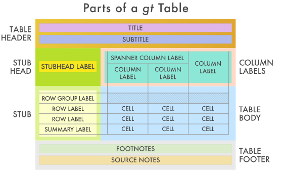

Todo comienza con los datos en una tabla (ya sea un tipo tibble o un data.frame).

Luego, se decide cómo componer la tabla con el **gt**,: los elementos y el formato que necesita para la tarea en cuestión.

Finalmente, la tabla se renderiza (*¿wtf?*) imprimiéndola en la consola, incluyéndola en un documento de R Markdown (para más tardito…), o exportándola a un archivo (usando “gtsave ()”). Actualmente, GT soporta salida HTML, con LaTeX y RTF planificados para el futuro.

¿No creen que es toda?

Veamos el workflow de la tabla **gt**:

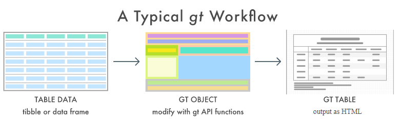

Esto lo que me está diciendo es que las tablas **gt** son creadas para luego ser exportadas.

Veamos algunos usos de las tablas mediante la función *gt()*.

Para esto utilizaremos un archido denominado *islands*, pero lo deberámos convertir a un objeto tibble antes:

```r
islands_tbl <-
  dplyr::tibble(
    name = names(islands),
    size = islands
  ) %>%
  dplyr::arrange(desc(size)) %>%
  dplyr::slice(1:10)

islands_tbl
```

```
## # A tibble: 10 x 2
##    name           size
##    <chr>         <dbl>
##  1 Asia          16988
##  2 Africa        11506
##  3 North America  9390
##  4 South America  6795
##  5 Antarctica     5500
##  6 Europe         3745
##  7 Australia      2968
##  8 Greenland       840
##  9 New Guinea      306
## 10 Borneo          280
```

#### gt simple

```r
gt_tbl <- gt(data = islands_tbl)

gt_tbl
```

| name | size |
| --- | --- |
| Asia | 16988 |
| Africa | 11506 |
| North America | 9390 |
| South America | 6795 |
| Antarctica | 5500 |
| Europe | 3745 |
| Australia | 2968 |
| Greenland | 840 |
| New Guinea | 306 |
| Borneo | 280 |

```r
# o islands_tbl  %>% gt()
```

A partir de esta tabla simple, es que vamos a comenzar a mejorar la tabla

Las partes (aproximadamente de arriba a abajo) son:

- El encabezado de la tabla (opcional; con un título y posiblemente un subtítulo).
- Las notas introductorias; contiene etiquetas de fila, opcionalmente dentro de grupos de filas que tienen etiquetas de grupo de filas y posiblemente etiquetas de resumen cuando hay un resumen).
- Las columnas (contiene etiquetas de columna, opcionalmente debajo de las etiquetas de columna de llave inglesa).
- El cuerpo de la tabla (contiene columnas y filas de celdas).
- El pie de página de la tabla (opcional; posiblemente con notas al pie y notas fuente).

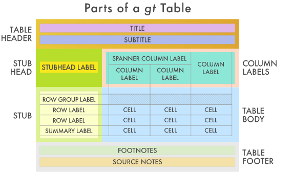

#### Titulo

```r
gt_tbl <-
  gt_tbl %>%
  tab_header(
    title = "Large Landmasses of the World",
    subtitle = "The top ten largest are presented"
  )

gt_tbl
```

Large Landmasses of the World

The top ten largest are presented

| name | size |
| --- | --- |
| Asia | 16988 |
| Africa | 11506 |
| North America | 9390 |
| South America | 6795 |
| Antarctica | 5500 |
| Europe | 3745 |
| Australia | 2968 |
| Greenland | 840 |
| New Guinea | 306 |
| Borneo | 280 |

Podemos hacer modificaciones al título

```r
gt(islands_tbl[1:2,]) %>%
  tab_header(
    title = md("**Large Landmasses of the World**"),
    subtitle = md("The *top two* largest are presented")
  )
```

**Large Landmasses of the World**

The *top two* largest are presented

| name | size |
| --- | --- |
| Asia | 16988 |
| Africa | 11506 |

#### Las notas al pie: fuente

```r
gt_tbl <-
  gt_tbl %>%
  tab_source_note(
    source_note = "Source: The World Almanac and Book of Facts, 1975, page 406."
  ) %>%
  tab_source_note(
    source_note = md("Reference: McNeil, D. R. (1977) *Interactive Data Analysis*. Wiley.")
  )

gt_tbl
```

Large Landmasses of the World

The top ten largest are presented

| name | size |
| --- | --- |
| Asia | 16988 |
| Africa | 11506 |
| North America | 9390 |
| South America | 6795 |
| Antarctica | 5500 |
| Europe | 3745 |
| Australia | 2968 |
| Greenland | 840 |
| New Guinea | 306 |
| Borneo | 280 |

Source: The World Almanac and Book of Facts, 1975, page 406.  
Reference: McNeil, D. R. (1977) *Interactive Data Analysis*. Wiley.

#### Las notas al pie: nota al pie

```r
# Add footnotes (the same text) to two different
# cell; data cells are targeted with `data_cells()`
gt_tbl <-
  gt_tbl %>%
  tab_footnote(
    footnote = "The Americas.",
    locations = cells_body(
      columns = vars(name),
      rows = 3:4)
  )

# Show the gt Table
gt_tbl
```

Large Landmasses of the World

The top ten largest are presented

| name | size |
| --- | --- |
| Asia | 16988 |
| Africa | 11506 |
| North America<sup>1</sup> | 9390 |
| South America<sup>1</sup> | 6795 |
| Antarctica | 5500 |
| Europe | 3745 |
| Australia | 2968 |
| Greenland | 840 |
| New Guinea | 306 |
| Borneo | 280 |

Source: The World Almanac and Book of Facts, 1975, page 406.  
Reference: McNeil, D. R. (1977) *Interactive Data Analysis*. Wiley.  
<sup>*1*</sup> The Americas.

Veamos otra modalidad

```r
largest <-
  islands_tbl %>%
  arrange(desc(size)) %>%
  slice(1) %>%
  pull(name)

# Create two additional footnotes, using the
# `columns` and `where` arguments of `data_cells()`
gt_tbl <-
  gt_tbl %>%
  tab_footnote(
    footnote = md("The **largest** by area."),
    locations = cells_body(
      columns = vars(size),
      rows = name == largest)
  ) %>%
  tab_footnote(
    footnote = "The lowest by population.",
    locations = cells_body(
      columns = vars(size),
      rows = size == min(size))
  )

gt_tbl
```

Large Landmasses of the World

The top ten largest are presented

| name | size |
| --- | --- |
| Asia | 16988<sup>1</sup> |
| Africa | 11506 |
| North America<sup>2</sup> | 9390 |
| South America<sup>2</sup> | 6795 |
| Antarctica | 5500 |
| Europe | 3745 |
| Australia | 2968 |
| Greenland | 840 |
| New Guinea | 306 |
| Borneo | 280<sup>3</sup> |

Source: The World Almanac and Book of Facts, 1975, page 406.  
Reference: McNeil, D. R. (1977) *Interactive Data Analysis*. Wiley.  
<sup>*1*</sup> The **largest** by area. <sup>*2*</sup> The Americas. <sup>*3*</sup> The lowest by population.

#### Columna matriz

```r
gt_tbl <-
  islands_tbl %>%
  gt(rowname_col = "name")

# Show the gt Table
gt_tbl
```

|  | size |
| --- | --- |
| Asia | 16988 |
| Africa | 11506 |
| North America | 9390 |
| South America | 6795 |
| Antarctica | 5500 |
| Europe | 3745 |
| Australia | 2968 |
| Greenland | 840 |
| New Guinea | 306 |
| Borneo | 280 |

Podemos ponerle nombre…

```r
gt_tbl <-
  gt_tbl %>%
  tab_stubhead(label = "landmass")


gt_tbl
```

| landmass | size |
| --- | --- |
| Asia | 16988 |
| Africa | 11506 |
| North America | 9390 |
| South America | 6795 |
| Antarctica | 5500 |
| Europe | 3745 |
| Australia | 2968 |
| Greenland | 840 |
| New Guinea | 306 |
| Borneo | 280 |

Veamos una tabla más estilizada

```r
gt_tbl <-
  gt_tbl %>%
  tab_header(
    title = "Large Landmasses of the World",
    subtitle = "The top ten largest are presented"
  ) %>%
  tab_source_note(
    source_note = "Source: The World Almanac and Book of Facts, 1975, page 406."
  ) %>%
  tab_source_note(
    source_note = md("Reference: McNeil, D. R. (1977) *Interactive Data Analysis*. Wiley.")
  ) %>%
  tab_footnote(
    footnote = md("The **largest** by area."),
    locations = cells_body(
      columns = vars(size),
      rows = largest)
  ) %>%
  tab_footnote(
    footnote = "The lowest by population.",
    locations = cells_body(
      columns = vars(size),
      rows = contains("arc"))
  )

gt_tbl
```

Large Landmasses of the World

The top ten largest are presented

| landmass | size |
| --- | --- |
| Asia | 16988<sup>1</sup> |
| Africa | 11506 |
| North America | 9390 |
| South America | 6795 |
| Antarctica | 5500<sup>2</sup> |
| Europe | 3745 |
| Australia | 2968 |
| Greenland | 840 |
| New Guinea | 306 |
| Borneo | 280 |

Source: The World Almanac and Book of Facts, 1975, page 406.  
Reference: McNeil, D. R. (1977) *Interactive Data Analysis*. Wiley.  
<sup>*1*</sup> The **largest** by area. <sup>*2*</sup> The lowest by population.

#### Las etiquetas de las columnas

Utilizamos otro archivo de datos, donde queremos diferenciar el tipo de información.

```r
airquality_m <-
  airquality %>%
  mutate(Year = 1973L) %>%
  slice(1:10)

# Create a display table using the `airquality`
# dataset; arrange columns into groups
gt_tbl <-
  gt(data = airquality_m) %>%
  tab_header(
    title = "New York Air Quality Measurements",
    subtitle = "Daily measurements in New York City (May 1-10, 1973)"
  ) %>%
  tab_spanner(
    label = "Time",
    columns = vars(Year, Month, Day)
  ) %>%
  tab_spanner(
    label = "Measurement",
    columns = vars(Ozone, Solar.R, Wind, Temp)
  )

# Show the gt Table
gt_tbl
```

New York Air Quality Measurements

Daily measurements in New York City (May 1-10, 1973)

| Measurement Ozone | Measurement Solar.R | Measurement Wind | Measurement Temp | Time Year | Time Month | Time Day |
| --- | --- | --- | --- | --- | --- | --- |
| 41 | 190 | 7.4 | 67 | 1973 | 5 | 1 |
| 36 | 118 | 8.0 | 72 | 1973 | 5 | 2 |
| 12 | 149 | 12.6 | 74 | 1973 | 5 | 3 |
| 18 | 313 | 11.5 | 62 | 1973 | 5 | 4 |
| NA | NA | 14.3 | 56 | 1973 | 5 | 5 |
| 28 | NA | 14.9 | 66 | 1973 | 5 | 6 |
| 23 | 299 | 8.6 | 65 | 1973 | 5 | 7 |
| 19 | 99 | 13.8 | 59 | 1973 | 5 | 8 |
| 8 | 19 | 20.1 | 61 | 1973 | 5 | 9 |
| NA | 194 | 8.6 | 69 | 1973 | 5 | 10 |

Igual, podemos desplazar las columnas a nuestra conveniencia

```r
gt_tbl <-
  gt_tbl %>%
  cols_move_to_start(
    columns = vars(Year, Month, Day)
  ) %>%
  cols_label(
    Ozone = html("Ozone,<br>ppbV"),
    Solar.R = html("Solar R.,<br>cal/m<sup>2</sup>"),
    Wind = html("Wind,<br>mph"),
    Temp = html("Temp,<br>&deg;F")
  )

gt_tbl
```

New York Air Quality Measurements

Daily measurements in New York City (May 1-10, 1973)

| Time Year | Time Month | Time Day | Measurement Ozone, ppbV | Measurement Solar R., cal/m<sup>2</sup> | Measurement Wind, mph | Measurement Temp, °F |
| --- | --- | --- | --- | --- | --- | --- |
| 1973 | 5 | 1 | 41 | 190 | 7.4 | 67 |
| 1973 | 5 | 2 | 36 | 118 | 8.0 | 72 |
| 1973 | 5 | 3 | 12 | 149 | 12.6 | 74 |
| 1973 | 5 | 4 | 18 | 313 | 11.5 | 62 |
| 1973 | 5 | 5 | NA | NA | 14.3 | 56 |
| 1973 | 5 | 6 | 28 | NA | 14.9 | 66 |
| 1973 | 5 | 7 | 23 | 299 | 8.6 | 65 |
| 1973 | 5 | 8 | 19 | 99 | 13.8 | 59 |
| 1973 | 5 | 9 | 8 | 19 | 20.1 | 61 |
| 1973 | 5 | 10 | NA | 194 | 8.6 | 69 |

#### **Ir más alla en el gt()**

Podría crear tablas con colores, con sup índices, y todas las modalidades habidas y por haber… ¿cool verdad?

```r
tooth_length <- ToothGrowth %>%
  group_by(supp, dose) %>%
  summarize(
    mean_len = mean(len)
  ) %>%
  as_tibble()
# A gt table:
tooth_length %>% # Take tooth_length
  gt() %>% # Make a gt table with it
  tab_header(
    title = "A title just like that", # Add a title
    subtitle = "(with something below it!)" # And a subtitle
  ) %>%
  fmt_passthrough( # Not sure about this but it works...
    columns = vars(supp) # First column: supp (character)
  ) %>%
  fmt_number(
    columns = vars(mean_len), # Second column: mean_len (numeric)
    decimals = 2 # With 4 decimal places
  ) %>%
  fmt_number(
    columns = vars(dose), # Third column: dose (numeric)
    decimals = 2 # With 2 decimal places
  ) %>%
  data_color( # Update cell colors...
    columns = vars(supp), # ...for supp column!
    colors = scales::col_factor( # <- bc it's a factor
      palette = c(
        "green","cyan"), # Two factor levels, two colors
      domain = c("OJ","VC")# Levels
  )
  ) %>%
  data_color( # Update cell colors...
    columns = vars(dose), # ...for dose column
    colors = scales::col_numeric( # <- bc it's numeric
      palette = c(
        "yellow","orange"), # A color scheme (gradient)
      domain = c(0.5,2) # Column scale endpoints
  )
  ) %>%
  data_color( # Update cell colors...
    columns = vars(mean_len), # ...for mean_len column
    colors = scales::col_numeric(
      palette = c(
        "red", "purple"), # Overboard colors!
      domain = c(7,27) # Column scale endpoints
  )
  ) %>%
  cols_label(supp = "Supplement", dose = "Dosage (mg/d)", mean_len = "Mean Tooth Length") %>% # Make the column headers
  tab_footnote(
    footnote = "Baby footnote test", # This is the footnote text
    locations = cells_column_labels(
      columns = vars(supp) # Associated with column 'supp'
      )
    ) %>%
    tab_footnote(
    footnote = "A second footnote", # Another line of footnote text
    locations = cells_column_labels(
      columns = vars(dose) # Associated with column 'dose'
      )
    )
```

A title just like that

(with something below it!)

| Supplement<sup>1</sup> | Dosage (mg/d)<sup>2</sup> | Mean Tooth Length |
| --- | --- | --- |
| OJ | 0.50 | 13.23 |
| OJ | 1.00 | 22.70 |
| OJ | 2.00 | 26.06 |
| VC | 0.50 | 7.98 |
| VC | 1.00 | 16.77 |
| VC | 2.00 | 26.14 |

<sup>*1*</sup> Baby footnote test <sup>*2*</sup> A second footnote

Veamos otro ejemplo:

```r
fake <- tribble( # Create a tibble...
  ~Species, ~Height, ~Mass, # These will be the column names (variables)
  "Blarg", 20500, 1980, # Row 1
  "Gorple", 17000, 775, # Row 2
  "Roglob", 11820, 20, # Row 3
  "Fwerpy", 8005, 352 # Row 4
) %>%
  arrange(-Mass) # Arrange high-to-low by values in Mass column

fake %>%
  gt() %>%
  tab_header(
    title = "Fake species data", # Add a title
    subtitle = "another useful subtitle" # And a subtitle
  ) %>%
  fmt_scientific( # Reformat to scientific notation...
    columns = vars(Height), # The values for the 'Height' variable
    decimals = 3 # Keeping 3 decimal places
  ) %>%
  fmt_scientific( # Reformat to scientific notation...
    columns = vars(Mass), # The values for the 'Mass' variable
    decimals = 1 # Keeping 1 decimal place
  ) %>%
  data_color( # Update cell colors...
    columns = vars(Mass), # ...for Mass column
    colors = scales::col_numeric( # <- bc it's numeric
      palette = c(
        "yellow", "red", "purple"), # A color scheme (gradient)
      domain = c(1e1, 2e3) # Column scale endpoints
  )
  )
```

Fake species data

another useful subtitle

| Species | Height | Mass |
| --- | --- | --- |
| Blarg | 2.050 × 10<sup>4</sup> | 2.0 × 10<sup>3</sup> |
| Gorple | 1.700 × 10<sup>4</sup> | 7.8 × 10<sup>2</sup> |
| Fwerpy | 8.005 × 10<sup>3</sup> | 3.5 × 10<sup>2</sup> |
| Roglob | 1.182 × 10<sup>4</sup> | 2.0 × 10<sup>1</sup> |

Tanto las opciones de **gt** como **kable** nacen para mejorar las tablas pensando en la exportación de estas en otro ambiente (word, .ppt, markdown, etc.).

## **reactable**

[figure not shown]

La librería **reactable** otra forma de hacer tablas interactivas.

Las principales ventajas de las tabas por **reactable** es que permite:

- Clasificación, filtrado, conpaginación
- Agrupación y agregación
- Formateo de columna incorporado
- Filas expandibles y tablas anidadas
- Estilo condicional
- Funciona a la perfección con documentos de R Markdown (mas tardecito…) y aplicaciones Shiny (¿wtf?)

La estrucurta de la función **reactable()** es la siguiente:

```r
reactable(
  data,
  columns = NULL,
  columnGroups = NULL,
  rownames = NULL,
  groupBy = NULL,
  sortable = TRUE,
  resizable = FALSE,
  filterable = FALSE,
  searchable = FALSE,
  defaultColDef = NULL,
  defaultColGroup = NULL,
  defaultSortOrder = "asc",
  defaultSorted = NULL,
  pagination = TRUE,
  defaultPageSize = 10,
  showPageSizeOptions = FALSE,
  pageSizeOptions = c(10, 25, 50, 100),
  paginationType = "numbers",
  showPagination = NULL,
  showPageInfo = TRUE,
  minRows = 1,
  details = NULL,
  defaultExpanded = FALSE,
  selection = NULL,
  selectionId = NULL,
  defaultSelected = NULL,
  onClick = NULL,
  highlight = FALSE,
  outlined = FALSE,
  bordered = FALSE,
  borderless = FALSE,
  striped = FALSE,
  compact = FALSE,
  wrap = TRUE,
  showSortIcon = TRUE,
  showSortable = FALSE,
  class = NULL,
  style = NULL,
  rowClass = NULL,
  rowStyle = NULL,
  fullWidth = TRUE,
  width = "auto",
  height = "auto",
  theme = getOption("reactable.theme"),
  language = getOption("reactable.language"),
  elementId = NULL
)
```

Nada del otro mundo….

Veamos un ejemplo de la función *reactable()* a partir de los datos de **iris**:

```r
library(reactable)
reactable(iris)
```

| Sepal.Length | Sepal.Width | Petal.Length | Petal.Width | Species |
| --- | --- | --- | --- | --- |
| 5.1 | 3.5 | 1.4 | 0.2 | setosa |
| 4.9 | 3 | 1.4 | 0.2 | setosa |
| 4.7 | 3.2 | 1.3 | 0.2 | setosa |
| 4.6 | 3.1 | 1.5 | 0.2 | setosa |
| 5 | 3.6 | 1.4 | 0.2 | setosa |
| 5.4 | 3.9 | 1.7 | 0.4 | setosa |
| 4.6 | 3.4 | 1.4 | 0.3 | setosa |
| 5 | 3.4 | 1.5 | 0.2 | setosa |
| 4.4 | 2.9 | 1.4 | 0.2 | setosa |
| 4.9 | 3.1 | 1.5 | 0.1 | setosa |

[output cut: 140 more lines]

**Agrupando y agregando**

```r
reactable(iris, groupBy = "Species", columns = list(
  Sepal.Length = colDef(aggregate = "count"),
  Sepal.Width = colDef(aggregate = "mean"),
  Petal.Length = colDef(aggregate = "sum"),
  Petal.Width = colDef(aggregate = "max")
))
```

| Sepal.Length | Sepal.Width | Petal.Length | Petal.Width | Species |
| --- | --- | --- | --- | --- |
| 5.1 | 3.5 | 1.4 | 0.2 | setosa |
| 4.9 | 3 | 1.4 | 0.2 | setosa |
| 4.7 | 3.2 | 1.3 | 0.2 | setosa |
| 4.6 | 3.1 | 1.5 | 0.2 | setosa |
| 5 | 3.6 | 1.4 | 0.2 | setosa |
| 5.4 | 3.9 | 1.7 | 0.4 | setosa |
| 4.6 | 3.4 | 1.4 | 0.3 | setosa |
| 5 | 3.4 | 1.5 | 0.2 | setosa |
| 4.4 | 2.9 | 1.4 | 0.2 | setosa |
| 4.9 | 3.1 | 1.5 | 0.1 | setosa |

[output cut: 140 more lines]

**Personalizar por condicionamiento**

```r
reactable(sleep, columns = list(
  extra = colDef(style = function(value) {
    if (value > 0) {
      color <- "green"
    } else if (value < 0) {
      color <- "red"
    } else {
      color <- "#777"
    }
    list(color = color, fontWeight = "bold")
  })
))
```

| extra | group | ID |
| --- | --- | --- |
| 0.7 | 1 | 1 |
| -1.6 | 1 | 2 |
| -0.2 | 1 | 3 |
| -1.2 | 1 | 4 |
| -0.1 | 1 | 5 |
| 3.4 | 1 | 6 |
| 3.7 | 1 | 7 |
| 0.8 | 1 | 8 |
| 0 | 1 | 9 |
| 2 | 1 | 10 |

[output cut: 10 more lines]

El siguiente enlace es una tabla realizada por la librería reactable:

https://projects.fivethirtyeight.com/2019-womens-world-cup-predictions/

También, las tablas de la revista *The Economist* son realizadas en **reactable**.

## **flextable**

[figure not shown]

El paquete **flextable** proporciona un *framework* con el fin crear fácilmente tablas para informes y publicaciones. Las tablas se pueden incrustar en:

- Documentos de R Markdown con soporte para documentos HTML, Word y PowerPoint.
- Documentos de Microsoft Word o PowerPoint con paquete oficial.
- Documentos PDF con paquete pagedown

Las tablas también se pueden renderizar (¿ahora sí?) como formatos de de R o archivos gráficos (.png, .pdf y .jpeg).

**flextable** puede crear fácilmente una tabla de informes a partir de un *data.frame*.

Puede

- fusionar celdas
- agregar filas de encabezado
- agregar filas de pie de página
- cambiar cualquier formato y
- Especificar cómo se deben mostrar los datos en las celdas.

El contenido de las tablas también puede contener un tipo mixto de contenido, texto e imágenes.

Los objetos *flextable()* se pueden renderizar en formato HTML, Microsoft Word, Microsoft PowerPoint y PDF.

La estrucuta de la función flextable es la siguiente:

```r
flextable(
  data,
  col_keys = names(data),
  cwidth = 0.75,
  cheight = 0.25,
  defaults = list(),
  theme_fun = theme_booktabs
)
```

La siguiente ilustración presenta la mayoría de las funciones disponibles para formatear una tabla *flextable()*:

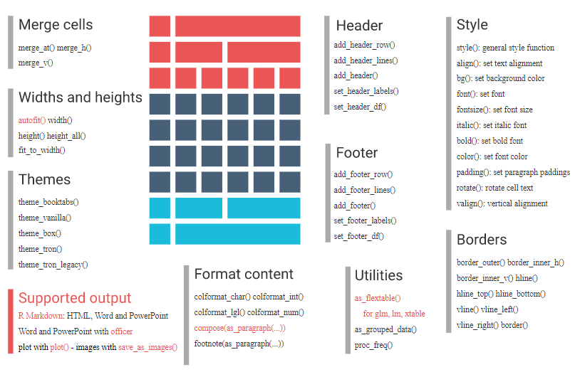

Veamos algún ejemplos

#### **flextable normal**

```r
library(flextable)
library(officer)
myft <- flextable(
  head(mtcars),
  col_keys = c("am", "carb", "gear", "mpg", "drat" ))
myft
```

| am | carb | gear | mpg | drat |
| --- | --- | --- | --- | --- |
| 1 | 4 | 4 | 21.0 | 3.90 |
| 1 | 4 | 4 | 21.0 | 3.90 |
| 1 | 1 | 4 | 22.8 | 3.85 |
| 0 | 1 | 3 | 21.4 | 3.08 |
| 0 | 2 | 3 | 18.7 | 3.15 |
| 0 | 1 | 3 | 18.1 | 2.76 |

#### **agregamos lineas**

```r
myft <- theme_vanilla(myft)
myft
```

| am | carb | gear | mpg | drat |
| --- | --- | --- | --- | --- |
| 1 | 4 | 4 | 21.0 | 3.90 |
| 1 | 4 | 4 | 21.0 | 3.90 |
| 1 | 1 | 4 | 22.8 | 3.85 |
| 0 | 1 | 3 | 21.4 | 3.08 |
| 0 | 2 | 3 | 18.7 | 3.15 |
| 0 | 1 | 3 | 18.1 | 2.76 |

#### **Damos un poco más de orde al cuadro**

```r
myft <- merge_v(myft, j = c("am", "carb") )
myft <- set_header_labels( myft, carb = "# carb." )
myft <- autofit(myft)
myft
```

| am | # carb. | gear | mpg | drat |
| --- | --- | --- | --- | --- |
| 1 | 4 | 4 | 21.0 | 3.90 |
|  |  | 4 | 21.0 | 3.90 |
|  | 1 | 4 | 22.8 | 3.85 |
| 0 |  | 3 | 21.4 | 3.08 |
|  | 2 | 3 | 18.7 | 3.15 |
|  | 1 | 3 | 18.1 | 2.76 |

#### **Personalizamos el cuadro**

```r
myft <- italic(myft, j = 1)
myft <- bg(myft, bg = "#C90000", part = "header")
myft <- color(myft, color = "white", part = "header")
myft <- color(myft, ~ drat > 3.5, ~ drat, color = "red")
myft <- bold(myft, ~ drat > 3.5, ~ drat, bold = TRUE)
myft <- autofit(myft)
myft
```

| am | # carb. | gear | mpg | drat |
| --- | --- | --- | --- | --- |
| 1 | 4 | 4 | 21.0 | 3.90 |
|  |  | 4 | 21.0 | 3.90 |
|  | 1 | 4 | 22.8 | 3.85 |
| 0 |  | 3 | 21.4 | 3.08 |
|  | 2 | 3 | 18.7 | 3.15 |
|  | 1 | 3 | 18.1 | 2.76 |

#### **Una salida más html**

```r
ft <- flextable(head(mtcars))
ft <- autofit(ft)
ft
```

| mpg | cyl | disp | hp | drat | wt | qsec | vs | am | gear | carb |
| --- | --- | --- | --- | --- | --- | --- | --- | --- | --- | --- |
| 21.0 | 6 | 160 | 110 | 3.90 | 2.620 | 16.46 | 0 | 1 | 4 | 4 |
| 21.0 | 6 | 160 | 110 | 3.90 | 2.875 | 17.02 | 0 | 1 | 4 | 4 |
| 22.8 | 4 | 108 | 93 | 3.85 | 2.320 | 18.61 | 1 | 1 | 4 | 1 |
| 21.4 | 6 | 258 | 110 | 3.08 | 3.215 | 19.44 | 1 | 0 | 3 | 1 |
| 18.7 | 8 | 360 | 175 | 3.15 | 3.440 | 17.02 | 0 | 0 | 3 | 2 |
| 18.1 | 6 | 225 | 105 | 2.76 | 3.460 | 20.22 | 1 | 0 | 3 | 1 |

Para una mayor referencia véase el siguiente enlace:

https://davidgohel.github.io/flextable/articles/overview.html

## **rhandsontable**

[figure not shown]

[figure not shown]

## **Referencias**

[figure not shown]

https://rstudio.github.io/DT/#:~:text=The%20R%20package%20DT%20provides,other%20features%20in%20the%20tables. https://www.rdocumentation.org/packages/DT/versions/0.15 https://blog.rstudio.com/2015/06/24/dt-an-r-interface-to-the-datatables-library/ https://shiny.rstudio.com/articles/datatables.html https://github.com/rstudio/DT

https://www.displayr.com/formattable/ https://cran.r-project.org/web/packages/formattable/vignettes/formattable-data-frame.html https://www.littlemissdata.com/blog/prettytables https://renkun-ken.github.io/formattable/ https://rfortherestofus.com/2019/11/how-to-make-beautiful-tables-in-r/

https://cran.r-project.org/web/packages/kableExtra/vignettes/awesome_table_in_html.html https://bookdown.org/yihui/rmarkdown-cookbook/kableextra.html http://gauss.inf.um.es:8080/tabular-tablas/ https://rpubs.com/yutao/444395

https://gt.rstudio.com/articles/intro-creating-gt-tables.html https://www.r-bloggers.com/great-looking-tables-gt-v0-2/ https://medium.com/the-artificial-impostor/playing-with-rstudio-gt-r-package-2f37a340c23f https://rdrr.io/github/rstudio/gt/

https://glin.github.io/reactable/ https://awesomeopensource.com/project/glin/reactable https://rdrr.io/github/glin/reactable/man/reactable-shiny.html https://towardsdatascience.com/recreate-publication-quality-interactive-tables-in-r-using-reactable-187407bc9702

https://davidgohel.github.io/flextable/articles/overview.html https://davidgohel.github.io/flextable/ https://www.user2019.fr/static/pres/t256480.pdf https://rdrr.io/cran/flextable/man/flextable.html

https://mran.revolutionanalytics.com/snapshot/2016-01-01/web/packages/rhandsontable/vignettes/intro_rhandsontable.html https://rdrr.io/cran/rhandsontable/man/hot_col.html https://github.com/jrowen/rhandsontable https://www.rdocumentation.org/packages/rhandsontable/versions/0.3.7/topics/rhandsontable https://cran.r-project.org/web/packages/rhandsontable/vignettes/intro_rhandsontable.html#:~:text=rhandsontable%20attempts%20to%20map%20R,to%20set%20strict%20to%20FALSE%20).

https://cran.r-project.org/web/packages/rpivotTable/vignettes/rpivotTableIntroduction.html https://cran.r-project.org/web/packages/rpivotTable/index.html https://www.r-bloggers.com/interactive-pivot-tables-with-r/